# Module 4: Data Processing and Storage

Somali Fish Stock Training

Author

Fisheries Management Team

Published

December 10, 2025

```r
require(sf)
require(tidyverse)
require(sizeMat)
require(gt)
require(tidyplots)
require(patchwork)
require(leaflet)
```

## Welcome to Module 4

**Data Processing and Storage**

### Learning Objectives

- Transform raw data into analysis-ready format
- Implement data cleaning workflows
- Establish secure storage protocols
- Create reproducible pipelines
- Document data provenance

### Why This Matters

- Raw data ≠ usable data
- Poor storage = data loss
- Reproducibility requires documentation
- Data governance enables sustainability
- Efficient workflows save time & resources

## Data Journey: Raw to Insights

### The Processing Pipeline:

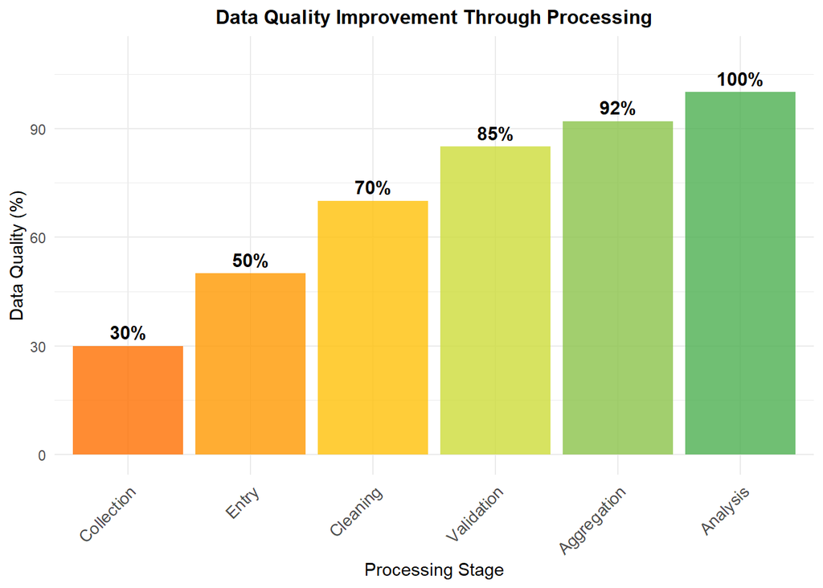

## Stage 1: Data Collection & Entry

### Field to Database:

- Paper forms captured in field
- Mobile apps with real-time sync
- Excel spreadsheets maintained locally
- Google Forms for simple surveys
- Manual transcription (highest error risk)

### Entry Quality Control:

- Range validation at entry time
- Dropdown menus prevent typos
- Required field checking
- Duplicate prevention

## Stage 2: Data Import into R

### Reading Common Formats:

```r
# Excel files
library(readxl)
data_raw <- read_excel('data_shared/raw_landings.xlsx', sheet = 'Section 3')

# CSV files
data_raw <- read.csv('landing_data.csv', stringsAsFactors = FALSE)

# Google Sheets
library(googlesheets4)
data_raw <- read_sheet('https://docs.google.com/spreadsheets/d/...')

# SPSS/Stata
library(haven)
data_raw <- read_sav('data.sav')
```

## Stage 3: Data Cleaning

### The 80/20 Rule:

80% of analysis time is spent cleaning data

### Common Issues:

```r
# Inconsistent region names
data |> distinct(region)
# Output: "Berbera", "berbera", "BERBERA", " Berbera"

# Missing values represented differently
# NA, "NA", "", "N/A", "missing", -999

# Impossible values
# Length: -5, 0, 500 cm
# Weight: -2, 0, 10000 kg
```

## Cleaning Step 1: Standardization

### Consistent Naming Conventions:

```r
data_clean <- data_raw |>
  # Standardize region names
  mutate(
    region = toupper(trimws(region)),
    region = recode(region,
      'BERBERA' = 'Berbera',
      'MOGADISHU' = 'Mogadishu',
      'KISMAYO' = 'Kismayo',
      'BORAMA' = 'Borama',
      'BAIDOA' = 'Baidoa',
      'GALKACYO' = 'Galkacyo'
    )
  ) |>
  # Standardize species names
  mutate(
    fish_group = tolower(trimws(fish_group)),
    fish_group = str_to_title(fish_group)
  )
```

## Cleaning Step 2: Date/Time Processing

### Temporal Data Handling:

```r
data_clean <- data_clean |>
  mutate(
    # Parse date field
    landing_date = as.Date(landing_date, format = '%d/%m/%Y'),

    # Extract temporal components
    year = year(landing_date),
    month = month(landing_date, label = TRUE),
    day_of_week = wday(landing_date, label = TRUE),
    week = week(landing_date),

    # Validate dates
    landing_date = if_else(
      landing_date > today() | landing_date < as.Date('2017-01-01'),
      NA_Date_,
      landing_date
    )
  )
```

## Cleaning Step 3: Outlier Detection

### Identifying Impossible Values:

```r
# Define biologically plausible ranges
data_clean <- data_raw |>
  mutate(
    # Flag suspicious lengths
    length_flag = case_when(
      length_cm < 5 ~ "too_small",
      length_cm > 200 ~ "too_large",
      is.na(length_cm) ~ "missing",
      TRUE ~ "valid"
    ),

    # Flag suspicious weights
    weight_flag = case_when(
      weight_kg < 0.1 ~ "too_light",
      weight_kg > 500 ~ "too_heavy",
      is.na(weight_kg) ~ "missing",
      TRUE ~ "valid"
    )
  )

# Review flagged records
data_clean |> filter(length_flag != "valid" | weight_flag != "valid")
```

## Cleaning Step 4: Handle Missing Values

### Missing Data Strategies:

**Option 1: Remove Records**

```r
# Remove if key variable missing
data_clean <- data_clean |>
  filter(!is.na(length_cm),
         !is.na(fish_group))
```

**Option 2: Impute**

```r
# Fill with group mean
data_clean <- data_clean |>
  group_by(fish_group) |>
  mutate(
    length_cm = coalesce(
      length_cm,
      mean(length_cm, na.rm = TRUE)
    )
  )
```

**Option 3: Mark as Special**

```r
# Keep but flag
data_clean <- data_clean |>
  mutate(
    length_missing = is.na(length_cm),
    length_cm = replace_na(length_cm, 0)
  )
```

**Option 4: Document**

```r
# Count missing by variable
data_clean |>
  summarise(
    across(everything(),
      list(missing = ~sum(is.na(.)))
    )
  )
```

## Cleaning Step 5: Duplicate Detection

### Finding Repeated Records:

```r
# Exact duplicates
data_clean |>
  janitor::get_dupes(
    landing_date, region, fish_group, length_cm
  )

# Near duplicates (same values, different timestamp)
data_clean |>
  group_by(region, landing_site, fish_group, length_cm) |>
  filter(n() > 1) |>
  arrange(region, landing_site, landing_date)
```

## Stage 4: Data Validation

### Statistical Checks:

```r
# Distribution review
data_clean |>
  group_by(fish_group) |>
  summarise(
    n = n(),
    mean_length = mean(length_cm, na.rm = TRUE),
    sd_length = sd(length_cm, na.rm = TRUE),
    min_length = min(length_cm, na.rm = TRUE),
    max_length = max(length_cm, na.rm = TRUE),
    .groups = 'drop'
  )

# Check for implausible relationships
data_clean |>
  filter(is.na(weight_kg) & !is.na(length_cm)) |>
  nrow() # How many length but no weight?
```

## Stage 5: Data Aggregation

### Creating Analysis Datasets:

```r
# Daily aggregates
daily_summary <- data_clean |>
  group_by(landing_date, region, landing_site) |>
  summarise(
    total_landings = n(),
    num_species = n_distinct(fish_group),
    mean_length = mean(length_cm, na.rm = TRUE),
    .groups = 'drop'
  )

# Monthly summaries
monthly_summary <- data_clean |>
  group_by(year, month, region, fish_group) |>
  summarise(
    catch = n(),
    mean_length = mean(length_cm, na.rm = TRUE),
    .groups = 'drop'
  )
```

## Data Storage Fundamentals

### Storage Decision Tree:

[figure not shown]

## Option 1: CSV Files (Simple)

### Advantages:

- ✓ Open format, no special software
- ✓ Version control friendly (Git)
- ✓ Human readable
- ✓ Easy to share and archive

### Disadvantages:

- ✗ No data types enforcement
- ✗ Slow for large files
- ✗ No built-in backup
- ✗ Concurrent access issues

### Best For:

Somali implementation with limited resources

## Option 2: SQLite Database (Local)

### Advantages:

- ✓ Single file format
- ✓ Fast queries
- ✓ Data integrity constraints
- ✓ No server required

### Disadvantages:

- ✗ Learning curve
- ✗ Limited concurrent users
- ✗ Backups manual

### Setup in R:

```r
library(RSQLite)

# Create connection
con <- dbConnect(SQLite(), 'fisheries_data.db')

# Write data
dbWriteTable(con, 'landings', data_clean,
             overwrite = TRUE)

# Query data
data_query <- dbGetQuery(con,
  'SELECT * FROM landings WHERE year = 2023')
```

## Option 3: Excel Workbooks (Moderate)

### Structured Multi-Sheet Approach:

```r
library(writexl)

# Create multi-sheet workbook
sheets <- list(
  'Raw Data' = data_raw,
  'Cleaned Data' = data_clean,
  'Daily Summary' = daily_summary,
  'Monthly Summary' = monthly_summary,
  'Data Dictionary' = data_dictionary
)

write_xlsx(sheets, 'fisheries_analysis.xlsx')
```

### Advantages:

- ✓ Familiar to most users
- ✓ Can include metadata
- ✓ Easy to share

## Recommended: Hybrid Approach

### For Somalia Implementation:

**Local Storage:**

```
Project Folder/
├── raw_data/
│   ├── 2024_berbera_landings.xlsx
│   ├── 2024_mogadishu_landings.xlsx
│   └── ...
├── processed_data/
│   ├── clean_landings_2024.csv
│   └── summary_tables.xlsx
├── scripts/
│   ├── 01_data_import.R
│   ├── 02_data_cleaning.R
│   └── 03_analysis.R
└── reports/
    ├── 2024_assessment.html
    └── figures/
```

## Creating a Data Dictionary

### Essential Documentation:

```r
data_dictionary <- tibble(
  Variable = c('landing_date', 'region', 'landing_site', 'fish_group', 'length_cm', 'weight_kg'),
  Description = c(
    'Date fish was landed',
    'Coastal region of Somalia',
    'Specific landing location',
    'Type of fish caught',
    'Fish fork length in centimeters',
    'Fish whole weight in kilograms'
  ),
  Type = c('Date', 'Character', 'Character', 'Character', 'Numeric', 'Numeric'),
  Units = c('YYYY-MM-DD', 'Text', 'Text', 'Category', 'cm', 'kg'),
  Range = c('2017-01-01 to today', 'Berbera, Mogadishu...', 'See lookup table', 'See lookup table', '5-200', '0.1-500'),
  Missing_Code = c('NA', 'NA', 'NA', 'NA', 'NA', 'NA')
)

write_xlsx(list('Dictionary' = data_dictionary), 'data_dictionary.xlsx')
```

## Reproducible Analysis Scripts

### Version 1: Linear Script

```r
# file: 01_analysis_berbera.R
# purpose: Monthly assessment for Berbera region
# author: [Your Name]
# date: 2024-01-15

# Load libraries
library(tidyverse)
library(gt)

# Import data
data_raw <- read.csv('raw_data/berbera_2024.csv')

# Clean and process
source('scripts/02_cleaning_functions.R')
data_clean <- clean_landing_data(data_raw)

# Analysis
results <- analyze_stock_status(data_clean)

# Output
write.csv(results, 'processed_data/berbera_results.csv')
```

## Version 2: Modular Approach

### Better for Maintenance:

```r
# file: functions/data_cleaning.R
clean_landing_data <- function(data) {
  data |>
    mutate(
      landing_date = as.Date(landing_date),
      region = toupper(trimws(region))
    ) |>
    filter(!is.na(length_cm)) |>
    filter(length_cm > 5 & length_cm < 200)
}

# file: functions/analysis.R
analyze_stock_status <- function(data) {
  data |>
    group_by(year, region, fish_group) |>
    summarise(
      mean_length = mean(length_cm, na.rm = TRUE),
      cpue = n() / n_distinct(landing_site),
      .groups = 'drop'
    )
}

# file: main_analysis.R
source('functions/data_cleaning.R')
source('functions/analysis.R')

data_clean <- clean_landing_data(data_raw)
results <- analyze_stock_status(data_clean)
```

## Backup & Disaster Recovery

### The 3-2-1 Rule:

**3 Copies** - Original - Local backup - Cloud backup

**2 Media Types** - Hard drive - Cloud storage - USB (offsite)

**1 Offsite** - Google Drive - OneDrive - Dropbox

## Backup Implementation

### Automated Backup Script:

```r
# file: backup.R
backup_data <- function() {
  timestamp <- format(Sys.time(), '%Y%m%d_%H%M%S')

  # Create backup directory
  dir.create('backups', showWarnings = FALSE)

  # Backup raw data
  file.copy(
    'raw_data/',
    paste0('backups/raw_', timestamp, '/'),
    recursive = TRUE
  )

  # Backup processed data
  file.copy(
    'processed_data/',
    paste0('backups/processed_', timestamp, '/'),
    recursive = TRUE
  )

  message(paste("Backup completed:", timestamp))
}

# Schedule weekly execution
# Windows: Task Scheduler
# Linux/Mac: cron job
```

## Version Control with Git

### Why Version Control Matters:

- Track changes to scripts
- Collaborate with team members
- Revert mistakes easily
- Document evolution
- Transparent workflow

### Basic Workflow:

```bash
# Initialize repository
git init

# Stage changes
git add data_cleaning.R

# Commit with message
git commit -m "Fix outlier detection for weights"

# Push to GitHub
git push origin main
```

## Data Access Control

### Protecting Sensitive Information:

```r
# Identify sensitive fields
sensitive_fields <- c('fisher_name', 'vessel_id', 'phone_number')

# Create anonymized version
data_public <- data_clean |>
  select(-all_of(sensitive_fields))

# Create restricted version for analysis
data_restricted <- data_clean |>
  filter(year == 2024)  # Current year only

# Save with different access levels
write.csv(data_public, 'shared/landing_data_public.csv')
write.csv(data_restricted, 'restricted/landing_data_internal.csv')
```

## Documentation Best Practices

### README File Template:

```markdown
# Somali Fisheries Landing Data

## Description
Monthly fish landing records from 6 coastal regions
(2017-2024)

## Data Dictionary
See `data_dictionary.xlsx`

## Processing Steps
1. Raw data entered in mobile app
2. Exported monthly to Excel
3. Cleaned in R (see scripts/)
4. Aggregated for analysis

## Contact
Data Manager: [name@email.com]

## Last Updated
2024-01-15
```

## Data Quality Reports

### Automated Quality Checks:

```r
generate_quality_report <- function(data) {
  report <- list(
    total_records = nrow(data),
    date_range = paste(
      min(data$landing_date), 'to', max(data$landing_date)
    ),
    missing_by_variable = colSums(is.na(data)),
    unique_regions = n_distinct(data$region),
    unique_species = n_distinct(data$fish_group),
    outliers_detected = sum(
      data$length_cm < 5 | data$length_cm > 200 |
      data$weight_kg < 0.1 | data$weight_kg > 500
    )
  )

  return(report)
}

quality_report <- generate_quality_report(data_clean)
```

## Pipeline Automation

### Complete Workflow Example:

```r
# file: monthly_pipeline.R
# Runs automatically first day of month

# 1. Import new data
new_data <- read.csv(Sys.getenv('NEW_DATA_FILE'))

# 2. Append to historical
historical <- read.csv('processed_data/all_landings.csv')
combined <- bind_rows(historical, new_data)

# 3. Clean
combined_clean <- clean_landing_data(combined)

# 4. Generate summaries
monthly_summary <- generate_monthly_summary(combined_clean)
annual_summary <- generate_annual_summary(combined_clean)

# 5. Create reports
render_assessment_report(monthly_summary)

# 6. Backup
backup_data()

# 7. Log
cat(
  paste("Pipeline completed", Sys.time()),
  file = 'logs/pipeline.log',
  append = TRUE
)
```

## Scaling Storage as Data Grows

### Growth Roadmap:

**Year 1 (Pilot):** - CSV files in OneDrive - Manual backups weekly - Single analyst

**Year 2 (Expansion):** - SQLite database - Automated backups daily - 2-3 team members

**Year 3+ (Full Operation):** - PostgreSQL server - Cloud hosting (AWS/Azure) - Regional coordinators - Real-time dashboards

## Training & Handover

### Documentation for Team:

```r
# Create onboarding guide
onboarding <- list(
  access = "How to access data systems",
  backup = "Weekly backup procedures",
  troubleshooting = "Common errors and fixes",
  contacts = "Who to contact for help",
  references = "Links to training materials"
)

# Create quick reference cards
quick_ref <- tibble(
  Task = c("Import data", "Clean outliers", "Generate report"),
  Command = c("source('scripts/import.R')",
              "source('scripts/clean.R')",
              "rmarkdown::render('report.Rmd')"),
  Notes = c("Set file path first", "Check ranges", "Check plots")
)
```

## Key Takeaways

### Module 4 Summary:

1. Data cleaning is 80% of analysis work
2. Standardization prevents errors later
3. Documentation enables reproducibility
4. Backups prevent data loss disasters
5. Version control tracks evolution
6. Automation improves efficiency
7. Access control protects data integrity
8. Scalability allows future growth

## Common Mistakes to Avoid

### Don’t:

- Modify raw data directly (keep original)
- Skip metadata documentation
- Ignore backup protocols
- Use manual data entry without QC
- Create many versions without naming
- Share sensitive data publicly
- Forget to document decisions
- Delete old files without review

## Practical Exercise

### Your Data Pipeline:

Design a processing workflow for your region:

1. **Input**: Where does data come from?
2. **Cleaning**: What issues will you address?
3. **Storage**: Where will you keep files?
4. **Backup**: How often and where?
5. **Output**: What reports do you need?

**Deliverable**: One-page data management plan

## Tools Summary

Data Processing Tools Comparison

For Somali implementation

| Tool | Purpose | Cost | Difficulty | Recommended |
| --- | --- | --- | --- | --- |
| R/RStudio | Analysis & scripting | Free | Medium | Yes |
| Git/GitHub | Version control | Free | Medium | Optional |
| OneDrive/Google Drive | Cloud backup | Free (limited) | Easy | Yes |
| SQLite | Database | Free | Medium | Optional |
| Excel | Simple storage | Paid | Easy | Yes |

## Resources & References

### R Documentation:

- R for Data Science (https://r4ds.had.co.nz/)
- tidyverse packages (tidyverse.org)
- Data cleaning guides

### Version Control:

- Git documentation (git-scm.com)
- GitHub Pages for hosting

### Data Management:

- FAIR data principles
- Open Data Foundation
- Data governance frameworks

## Integration with Previous Modules

### Complete Workflow:

1. **Module 1**: Understand data needs
2. **Module 2**: Collect quality data
3. **Module 3**: Analyze stocks
4. **Module 4**: Process & store data
5. **Repeat**: Continuous improvement

## Next Steps

### After Module 4:

**Note**

1. Set up your data folder structure
2. Create a data dictionary for your region
3. Write cleaning functions
4. Establish backup procedures
5. Document your workflow
6. Train team members

## Questions & Discussion

### Topics for Discussion:

- What storage option works best for you?
- What challenges do you anticipate?
- How will you train others?
- What tools can you access?
- How will you scale over time?

## Thank You

**Somali Fish Stock Training**

**Module 4: Data Processing and Storage**

*Building sustainable, scalable data systems*

Next: Advanced applications and regional coordination

Questions? Contact the training team.